# uschronicsdesease

## Research Question

How do the prevalence, trends, and demographic disparities of chronic diseases (e.g., diabetes, asthma, mental health) vary across the United States, and what are the underlying factors driving these patterns?

Chronic diseases, such as diabetes, asthma, and mental health conditions, are leading causes of morbidity and mortality in the United States. However, the burden of these diseases is not evenly distributed across states or demographic groups. Socioeconomic factors, healthcare access, environmental conditions, and systemic inequities contribute to significant variations in chronic disease prevalence and trends. Understanding these patterns is critical for addressing health disparities and designing targeted interventions.

- Prevalence by State:

Chronic disease prevalence varies widely across states, with some states experiencing significantly higher rates than others. Identifying the most prevalent chronic diseases and their geographic distribution can help prioritize public health efforts and allocate resources effectively. for example we can looking at those specific aspect: What are the most prevalent chronic diseases in the U.S., and how do they vary by state? Which states have the highest and lowest prevalence rates, and what factors contribute to these differences?

- Trends Over Time:

Chronic disease prevalence has evolved over time, with some conditions. Understanding trends can reveal the impact of public health policies, environmental changes, and socioeconomic shifts on chronic disease outcomes. For example we can look at : How have chronic disease indicators (e.g., diabetes, asthma, mental health) changed over time, and what are the underlying drivers of these trends?

- Demographic Disparities:

Chronic diseases disproportionately affect certain demographic groups, including low-income populations, communities of color, and specific age groups. For example we can looking at the diabetes prevalence among African American and Hispanic populations. Which demographic groups (e.g., age, sex, race/ethnicity) are most affected by specific chronic diseases, and how do socioeconomic factors contribute to these disparities?

By addressing these questions, this study aims to provide a comprehensive understanding of the prevalence, trends, and disparities in chronic diseases across the U.S. The findings will inform targeted public health interventions, resource allocation, and policy development to reduce health inequities and improve outcomes for vulnerable populations.

## Problem Statement

Chronic diseases, such as diabetes, asthma, and mental health conditions, are among the leading causes of morbidity and mortality in the United States. However, the burden of these diseases is not evenly distributed across states or demographic groups. Significant variations exist in chronic disease prevalence, with some states and populations experiencing disproportionately higher rates due to socioeconomic inequities, limited access to healthcare, and environmental stressors. Additionally, trends in chronic disease prevalence have evolved over time, with certain conditions increasing in prevalence while others have declined, influenced by factors such as public health policies, environmental changes, and socioeconomic shifts.

Despite advances in medical research and public health initiatives, disparities in chronic disease outcomes persist, particularly among marginalized communities, including low-income populations, communities of color, and specific age groups. These disparities are driven by systemic inequities, such as income inequality, unemployment, and limited access to quality healthcare, which create barriers to prevention, early detection, and effective management of chronic conditions.

## Data Description

https://catalog.data.gov/dataset/u-s-chronic-disease-indicators The U.S. Chronic Disease Indicators (CDI) dataset is provided by the CDC’s Division of Population Health. It consists of 309,215 records covering 115 key health indicators related to chronic diseases across all U.S. states and territories. This dataset is designed to provide a standardized approach for collecting, analyzing, and reporting chronic disease data to support public health decision-making.

## Import the libraries

```python
# Import the libraries
import numpy as np                  # Scientific Computing
import pandas as pd                 # Data Analysis
import matplotlib.pyplot as plt     # Plotting
import seaborn as sns               # Statistical Data Visualization

# Let's make sure pandas returns all the rows and columns for the dataframe
pd.set_option('display.max_rows', None)
pd.set_option('display.max_columns', None)

# Force pandas to display full numbers instead of scientific notation
# pd.options.display.float_format = '{:.0f}'.format

# Library to suppress warnings
import warnings
warnings.filterwarnings('ignore')
```

### Read the dataset

```python
# Read the dataset
path = pd.read_csv('U.S._Chronic_Disease_Indicators.csv')

# Create the Dataframe
us_chronic_desease = pd.DataFrame(path)
```

### Understanding the Dataset

- Checking first elements of the DataFrame with .head( ) method
- After you run the code above, nothing will appear.
- So you have to write df to see your data. But instead of seeing all the data, we are going to use the “.head( )” method to see the first five elements of the data.
- Before you run the read_csv code, you can write df.head( ) below. So it’s going to be like this:

Inside the parentheses, we can write the number of elements that we want to see. If we leave it blank, it will show the first five elements. If we write 7 inside of the parentheses, it will show the first 7 elements of the dataframe.

```python
# Display the first ten rows of the Dataframe
us_chronic_desease.head(7)
```

|  | YearStart | YearEnd | LocationAbbr | LocationDesc | DataSource | Topic | Question | Response | DataValueUnit | DataValueType | DataValue | DataValueAlt | DataValueFootnoteSymbol | DataValueFootnote | LowConfidenceLimit | HighConfidenceLimit | StratificationCategory1 | Stratification1 | StratificationCategory2 | Stratification2 | StratificationCategory3 | Stratification3 | Geolocation | LocationID | TopicID | QuestionID | ResponseID | DataValueTypeID | StratificationCategoryID1 | … |
| --- | --- | --- | --- | --- | --- | --- | --- | --- | --- | --- | --- | --- | --- | --- | --- | --- | --- | --- | --- | --- | --- | --- | --- | --- | --- | --- | --- | --- | --- | --- |
| 0 | 2019 | 2019 | AR | Arkansas | BRFSS | Diabetes | Diabetes among adults | NaN | % | Crude Prevalence | 13.6 | 13.6 | NaN | NaN | 12.1 | 15.4 | Sex | Male | NaN | NaN | NaN | NaN | POINT (-92.27449074299966 34.74865012400045) | 5 | DIA | DIA01 | NaN | CRDPREV | SEX | … |
| 1 | 2019 | 2019 | ID | Idaho | BRFSS | Diabetes | Diabetes among adults | NaN | % | Crude Prevalence | 10.6 | 10.6 | NaN | NaN | 9.1 | 12.2 | Sex | Male | NaN | NaN | NaN | NaN | POINT (-114.3637300419997 43.682630005000476) | 16 | DIA | DIA01 | NaN | CRDPREV | SEX | … |
| 2 | 2019 | 2019 | IN | Indiana | YRBSS | Sleep | Short sleep duration among high school students | NaN | % | Crude Prevalence | NaN | NaN | * | No data available | NaN | NaN | Grade | Grade 12 | NaN | NaN | NaN | NaN | POINT (-86.14996019399968 39.766910452000445) | 18 | SLEP | SLP02 | NaN | CRDPREV | GRADE | … |
| 3 | 2019 | 2019 | IA | Iowa | NVSS | Asthma | Asthma mortality among all people, underlying ... | NaN | Number | Number | 54.0 | 54.0 | NaN | NaN | NaN | NaN | Overall | Overall | NaN | NaN | NaN | NaN | POINT (-93.81649055599968 42.46940091300047) | 19 | AST | AST01 | NaN | NMBR | OVERALL | … |
| 4 | 2019 | 2019 | IA | Iowa | BRFSS | Asthma | Current asthma among adults | NaN | % | Crude Prevalence | 10.3 | 10.3 | NaN | NaN | 9.1 | 11.7 | Age | Age 18-44 | NaN | NaN | NaN | NaN | POINT (-93.81649055599968 42.46940091300047) | 19 | AST | AST02 | NaN | CRDPREV | AGE | … |
| 5 | 2019 | 2019 | IA | Iowa | NVSS | Diabetes | Diabetes mortality among all people, underlyin... | NaN | Number | Number | 54.0 | 54.0 | NaN | NaN | NaN | NaN | Age | Age 0-44 | NaN | NaN | NaN | NaN | POINT (-93.81649055599968 42.46940091300047) | 19 | DIA | DIA03 | NaN | NMBR | AGE | … |
| 6 | 2019 | 2019 | IA | Iowa | BRFSS | Health Status | Recent activity limitation among adults | NaN | Number | Crude Mean | 2.3 | 2.3 | NaN | NaN | 2.1 | 2.5 | Sex | Female | NaN | NaN | NaN | NaN | POINT (-93.81649055599968 42.46940091300047) | 19 | HEA | HEA04 | NaN | CRDMEAN | SEX | … |

Checking last elements of the DataFrame with .tail() method There is also a method to see the see last n number of elements. The method is called .tail(). The same rule is also applied here. If we leave the parentheses blank, it will be set as 5, if we write 7 inside of the parentheses, it will show the last 7 elements of the dataframe.

```python
# Display the last ten rows of the dataframe
# Syntax: DataFrame.tail(qty)
us_chronic_desease.tail(7)
```

|  | YearStart | YearEnd | LocationAbbr | LocationDesc | DataSource | Topic | Question | Response | DataValueUnit | DataValueType | DataValue | DataValueAlt | DataValueFootnoteSymbol | DataValueFootnote | LowConfidenceLimit | HighConfidenceLimit | StratificationCategory1 | Stratification1 | StratificationCategory2 | Stratification2 | StratificationCategory3 | Stratification3 | Geolocation | LocationID | TopicID | QuestionID | ResponseID | DataValueTypeID | StratificationCategoryID1 | … |
| --- | --- | --- | --- | --- | --- | --- | --- | --- | --- | --- | --- | --- | --- | --- | --- | --- | --- | --- | --- | --- | --- | --- | --- | --- | --- | --- | --- | --- | --- | --- |
| 309208 | 2022 | 2022 | VT | Vermont | BRFSS | Sleep | Short sleep duration among adults | NaN | % | Crude Prevalence | 26.5 | 26.5 | NaN | NaN | 16.8 | 39.3 | Race/Ethnicity | Asian, non-Hispanic | NaN | NaN | NaN | NaN | POINT (-72.51764079099962 43.62538123900049) | 50 | SLEP | SLP03 | NaN | CRDPREV | RACE | … |
| 309209 | 2022 | 2022 | VI | Virgin Islands | BRFSS | Immunization | Influenza vaccination among adults | NaN | % | Crude Prevalence | 34.2 | 34.2 | NaN | NaN | 24.2 | 45.8 | Age | Age >=65 | NaN | NaN | NaN | NaN | POINT (-64.896335 18.335765) | 78 | IMM | IMM01 | NaN | CRDPREV | AGE | … |
| 309210 | 2022 | 2022 | VI | Virgin Islands | BRFSS | Tobacco | Quit attempts in the past year among adult cur... | NaN | % | Age-adjusted Prevalence | NaN | NaN | # | No data available for this indicator because t... | NaN | NaN | Race/Ethnicity | American Indian or Alaska Native, non-Hispanic | NaN | NaN | NaN | NaN | POINT (-64.896335 18.335765) | 78 | TOB | TOB06 | NaN | AGEADJPREV | RACE | … |
| 309211 | 2022 | 2022 | WV | West Virginia | BRFSS | Chronic Obstructive Pulmonary Disease | Chronic obstructive pulmonary disease among ad... | NaN | % | Crude Prevalence | 14.0 | 14.0 | NaN | NaN | 12.8 | 15.2 | Overall | Overall | NaN | NaN | NaN | NaN | POINT (-80.71264013499967 38.66551020200046) | 54 | COPD | COPD01 | NaN | CRDPREV | OVERALL | … |
| 309212 | 2022 | 2022 | WI | Wisconsin | BRFSS | Immunization | Pneumococcal vaccination among adults aged 65 ... | NaN | % | Crude Prevalence | 64.2 | 64.2 | NaN | NaN | 52.2 | 74.6 | Race/Ethnicity | Black, non-Hispanic | NaN | NaN | NaN | NaN | POINT (-89.81637074199966 44.39319117400049) | 55 | IMM | IMM04 | NaN | CRDPREV | RACE | … |
| 309213 | 2022 | 2022 | VT | Vermont | BRFSS | Social Determinants of Health | Lack of health insurance among adults aged 18-... | NaN | % | Crude Prevalence | NaN | NaN | **** | Data suppressed; denominator < 50 or relative ... | NaN | NaN | Race/Ethnicity | Hawaiian or Pacific Islander, non-Hispanic | NaN | NaN | NaN | NaN | POINT (-72.51764079099962 43.62538123900049) | 50 | SDOH | SDH09 | NaN | CRDPREV | RACE | … |
| 309214 | 2022 | 2022 | WA | Washington | BRFSS | Alcohol | Binge drinking prevalence among adults | NaN | % | Age-adjusted Prevalence | 19.2 | 19.2 | NaN | NaN | 18.3 | 20.2 | Sex | Male | NaN | NaN | NaN | NaN | POINT (-120.47001078999972 47.52227862900048) | 53 | ALC | ALC06 | NaN | AGEADJPREV | SEX | … |

```python
# display the dimensions of the data
# This is the number of rows and columns in the data
# Syntax: DataFrame.shape
us_chronic_desease.shape
```

```
(309215, 34)
```

```python
309215*34
```

```
10513310
```

- State the shape of the dataframe :
  - The dataframe have 309215 rows
  - The dataframe have 34 Columns
  - There are 10513310 total datapoints observed i my dataset.

### Data Types

- The main data types in Pandas dataframes are `object`, `float`, `int64`, `bool` and `datetime64`. In order to understand each attribute of the data, it is always good to know the data type of each column.

##### `.info()` method

- This method prints information about a DataFrame including the index `dtype` and column dtypes, non-null values and memory usage.

```python
# Let's check the basic information about the dataset
# Syntax: DataFrame.info()
us_chronic_desease.info(show_counts=True, verbose=True)
```

```
<class 'pandas.core.frame.DataFrame'>
RangeIndex: 309215 entries, 0 to 309214
Data columns (total 34 columns):
 #   Column                     Non-Null Count   Dtype
---  ------                     --------------   -----
 0   YearStart                  309215 non-null  int64
 1   YearEnd                    309215 non-null  int64
 2   LocationAbbr               309215 non-null  object
 3   LocationDesc               309215 non-null  object
 4   DataSource                 309215 non-null  object
 5   Topic                      309215 non-null  object
 6   Question                   309215 non-null  object
 7   Response                   0 non-null       float64
 8   DataValueUnit              309215 non-null  object
 9   DataValueType              309215 non-null  object
```

[output cut: 26 more lines]

### Observations of the Data Set

Describe the dataset.

The number of non-null values does not match the total number expected based on the number of rows in the dataframe. This indicates the presence of missing values that will need further investigation.

# Data Cleaning:

## Data Analysis and Preparation

The steps of analysis and preparation of the data for statistical modeling has several steps:

1. Check dimensions of the dataframe to determine the number rows and columns. This increases understanding of the data structure and size.
2. Check data types, ensuring the data types are correct. Refer data definitions to validate the results. For example dates including year, month, and day should be updated from integers or strings to `datetime` for ease of use in time series analysis.
3. Update data types based on the business definition, changing the data types as per requirement.
4. Using Python and Numpy methods, examine the summary statistics. This assists in determination of the data scale, including the relative minima and maxima for the range. The distribution of data with early determination of skewness or kurtosis are also visible for outliers in the data.
5. Checking for missing values that may cause noise in machine learning models and abberations in visualizations.
6. Study the correlation between data variables for key insights and future feature engineering.
7. Detection of outliers that may contribute to the skewness in data or add to the kurtosis affecting the data ranges.

### Headers Update and Map New Column

>

- To aid in analysis and visualization add a new columns as needed. For instance instead of an entire state name, add a column that has a two letter abbreviation for the state.
- The list of headers requires standardization, these will be updated ensure uniformity.
- Update ALL CAPS or all lowercase to the appropriate case. These can be updated to Title Case.

```python
# Let's create a list of the columns in the dataset
# Use the variable = DataFrame.columns method
chroniccols=us_chronic_desease.columns
chroniccols
```

```
Index(['YearStart', 'YearEnd', 'LocationAbbr', 'LocationDesc', 'DataSource',
       'Topic', 'Question', 'Response', 'DataValueUnit', 'DataValueType',
       'DataValue', 'DataValueAlt', 'DataValueFootnoteSymbol',
       'DataValueFootnote', 'LowConfidenceLimit', 'HighConfidenceLimit',
       'StratificationCategory1', 'Stratification1', 'StratificationCategory2',
       'Stratification2', 'StratificationCategory3', 'Stratification3',
       'Geolocation', 'LocationID', 'TopicID', 'QuestionID', 'ResponseID',
       'DataValueTypeID', 'StratificationCategoryID1', 'StratificationID1',
       'StratificationCategoryID2', 'StratificationID2',
       'StratificationCategoryID3', 'StratificationID3'],
      dtype='object')
```

```python
# Let's Update the Headers for Syntax Consistency
# Syntax: df = df.rename(columns={'currentColumnName':'newColumnName', 'nextCurrentColumnName':'nextNewColumnName'})
us_chronic_desease.rename(columns= {'YearStart':'Yearstart',
                                   'YearEnd':'Yearend',
                                   'DataValueUnit':'Unit(DV)',
                                   'DataValueType':'Type(DV)',
                                   'DataValue':'DataValue(DV)',
                                   'DataValueAlt':'Alt(DV)',
                                   'DataValueFootnoteSymbol':'FootnoteSymbol(DV)',
                                   'DataValueFootnote':'Footnote(DV)'
                                   })
# Let's view the new columns and update the variable
# Pass the columns to the variable: Use the variable = DataFrame.columns method
Chroniccols=us_chronic_desease.columns
# Call the variable to see the contents
us_chronic_desease.head()
```

|  | YearStart | YearEnd | LocationAbbr | LocationDesc | DataSource | Topic | Question | Response | DataValueUnit | DataValueType | DataValue | DataValueAlt | DataValueFootnoteSymbol | DataValueFootnote | LowConfidenceLimit | HighConfidenceLimit | StratificationCategory1 | Stratification1 | StratificationCategory2 | Stratification2 | StratificationCategory3 | Stratification3 | Geolocation | LocationID | TopicID | QuestionID | ResponseID | DataValueTypeID | StratificationCategoryID1 | … |
| --- | --- | --- | --- | --- | --- | --- | --- | --- | --- | --- | --- | --- | --- | --- | --- | --- | --- | --- | --- | --- | --- | --- | --- | --- | --- | --- | --- | --- | --- | --- |
| 0 | 2019 | 2019 | AR | Arkansas | BRFSS | Diabetes | Diabetes among adults | NaN | % | Crude Prevalence | 13.6 | 13.6 | NaN | NaN | 12.1 | 15.4 | Sex | Male | NaN | NaN | NaN | NaN | POINT (-92.27449074299966 34.74865012400045) | 5 | DIA | DIA01 | NaN | CRDPREV | SEX | … |
| 1 | 2019 | 2019 | ID | Idaho | BRFSS | Diabetes | Diabetes among adults | NaN | % | Crude Prevalence | 10.6 | 10.6 | NaN | NaN | 9.1 | 12.2 | Sex | Male | NaN | NaN | NaN | NaN | POINT (-114.3637300419997 43.682630005000476) | 16 | DIA | DIA01 | NaN | CRDPREV | SEX | … |
| 2 | 2019 | 2019 | IN | Indiana | YRBSS | Sleep | Short sleep duration among high school students | NaN | % | Crude Prevalence | NaN | NaN | * | No data available | NaN | NaN | Grade | Grade 12 | NaN | NaN | NaN | NaN | POINT (-86.14996019399968 39.766910452000445) | 18 | SLEP | SLP02 | NaN | CRDPREV | GRADE | … |
| 3 | 2019 | 2019 | IA | Iowa | NVSS | Asthma | Asthma mortality among all people, underlying ... | NaN | Number | Number | 54.0 | 54.0 | NaN | NaN | NaN | NaN | Overall | Overall | NaN | NaN | NaN | NaN | POINT (-93.81649055599968 42.46940091300047) | 19 | AST | AST01 | NaN | NMBR | OVERALL | … |
| 4 | 2019 | 2019 | IA | Iowa | BRFSS | Asthma | Current asthma among adults | NaN | % | Crude Prevalence | 10.3 | 10.3 | NaN | NaN | 9.1 | 11.7 | Age | Age 18-44 | NaN | NaN | NaN | NaN | POINT (-93.81649055599968 42.46940091300047) | 19 | AST | AST02 | NaN | CRDPREV | AGE | … |

```python
# Let's update the string text in headers to Title case.
# Syntax: df['column'].str.title()
us_chronic_desease['StratificationCategoryID1'].str.title()

# Let's See the results using the .head() method
# Syntax: DataFrame.head(qty)

#us_chronic_desease.head(10)
```

```
0             Sex
1             Sex
2           Grade
3         Overall
4             Age
5             Age
6             Sex
7            Race
8             Age
9            Race
10            Sex
11            Age
12            Sex
13            Sex
14            Sex
```

[output cut: 309201 more lines]

```python
# Determine the number of missing values
# Syntax: DataFrame.isnull().sum()
us_chronic_desease.isnull().sum()
```

```
YearStart                         0
YearEnd                           0
LocationAbbr                      0
LocationDesc                      0
DataSource                        0
Topic                             0
Question                          0
Response                     309215
DataValueUnit                     0
DataValueType                     0
DataValue                    100019
DataValueAlt                 100019
DataValueFootnoteSymbol      207499
DataValueFootnote            207499
LowConfidenceLimit           120330
HighConfidenceLimit          120325
StratificationCategory1           0
Stratification1                   0
StratificationCategory2      309215
Stratification2              309215
StratificationCategory3      309215
Stratification3              309215
Geolocation                    5763
LocationID                        0
TopicID                           0
QuestionID                        0
ResponseID                   309215
DataValueTypeID                   0
StratificationCategoryID1         0
StratificationID1                 0
StratificationCategoryID2    309215
StratificationID2            309215
StratificationCategoryID3    309215
StratificationID3            309215
dtype: int64
```

```python
# Let's create a function to determine the percentage of missing values
# Typically less than five percent missing values may not affect the results
# More than 5% can be dropped, replaced with existing data, or imputed using mean or median.
# Syntax: def missing(DataFrame):
#    print ('Percentage of missing values in the dataset:\n',
#           round((DataFtame.isnull().sum() * 100/ len(DataFrame)),2).sort_values(ascending=False))
def missing(DataFrame):
    print('Percentage of missing values in the dataset:\n',round((DataFrame.isnull().sum()*100/len(DataFrame)),2).sort_values(ascending=False))


    # Call the function and execute
# Syntax: missing(DataFrame)
missing(us_chronic_desease)
```

```
Percentage of missing values in the dataset:
 StratificationID3            100.00
StratificationCategoryID3    100.00
StratificationID2            100.00
StratificationCategoryID2    100.00
Stratification3              100.00
StratificationCategory3      100.00
Response                     100.00
Stratification2              100.00
ResponseID                   100.00
StratificationCategory2      100.00
DataValueFootnoteSymbol       67.11
DataValueFootnote             67.11
LowConfidenceLimit            38.91
HighConfidenceLimit           38.91
DataValueAlt                  32.35
DataValue                     32.35
Geolocation                    1.86
LocationID                     0.00
QuestionID                     0.00
TopicID                        0.00
DataValueTypeID                0.00
StratificationCategoryID1      0.00
StratificationID1              0.00
YearStart                      0.00
YearEnd                        0.00
StratificationCategory1        0.00
DataValueType                  0.00
DataValueUnit                  0.00
Question                       0.00
Topic                          0.00
DataSource                     0.00
LocationDesc                   0.00
LocationAbbr                   0.00
Stratification1                0.00
dtype: float64
```

### Observations

- How many missing values are there?

The dataset contains a significant amount of missing values, particularly in several stratification-related columns and response fields. Here are the key observations:

100% missing values in multiple columns, including:

StratificationID3, StratificationCategoryID3, StratificationID2, StratificationCategoryID2, Stratification3, StratificationCategory3, Response, Stratification2, ResponseID, StratificationCategory2. These columns provide no usable data and may need to be dropped or imputed if necessary. 67.11% missing values in DataValueFootnoteSymbol and DataValueFootnote, which suggests partial missingness in data annotations.

38.91% missing values in LowConfidenceLimit and HighConfidenceLimit, which may impact confidence intervals for reported data values.

32.35% missing values in DataValueAlt and DataValue, which are core numerical fields, potentially affecting analysis reliability.

Minimal or no missing values (0.00%) in key categorical and structural fields like LocationID, YearStart, YearEnd, Question, Topic, and DataValueTypeID, meaning the dataset retains essential metadata for analysis.

- Are these concentrated in specific rows or columns?

The missing values are concentrated in specific columns, particularly in stratification-related fields and response-related data. Impact on analysis: Columns with 100% missing values contribute nothing and should be removed unless they are needed for merging with another dataset. Missing values in DataValue and Confidence Limits affect quantitative analysis, especially when computing trends, averages, or statistical significance. Geolocation has minimal missing data (1.86%), meaning most location-based analysis is still reliable.

The following columns have missing values on they entire columns **StratificationID3, StratificationCategoryID3, StratificationID2,StratificationCategoryID2, Stratification3, StratificationCategory3, Response,Stratification2,ResponseID, StratificationCategory2 and DataValueFootnoteSymbol, DataValueFootnote has 67.11, LowConfidenceLimit ,HighConfidenceLimit 38.91 DataValueAlt,DataValue 32.35 Geolocation 1.86**

Based on the information that is present, how should the missing values be handled? How will this affect the analysis?

- Drop columns with 100% missing values – they do not contribute to analysis.
- Impute missing values for DataValue, LowConfidenceLimit, and HighConfidenceLimit:
- Use mean/median imputation if data is missing at random.
- Use predictive modeling (e.g., regression) if missing values are systematic.

Impact on analysis: Removing fully empty columns simplifies the dataset without loss of information. Imputing missing numerical values ensures statistical calculations remain valid. Keeping location-based fields intact allows geospatial insights to remain accurate.

```python
# Drop the columns by name
# Use either labels=[list] and columns=labels or columns=[list]
# let's Create a list of columns t be droped
dropcols=['StratificationID3',
'StratificationCategoryID3',
'StratificationID2',
'StratificationCategoryID2' ,
'Stratification3',
'StratificationCategory3',
'Response',
'Stratification2'
,'ResponseID'
,'StratificationCategory2']
# Syntax: DataFrame.drop(labels=None, *, axis=0, index=None, columns=None, level=None, inplace=False, errors='raise')
us_chronic_desease= us_chronic_desease.drop(columns=dropcols)

# Drop the rows
# Syntax: DataFrame.dropna(*, axis=0, how=_NoDefault.no_default, thresh=_NoDefault.no_default, subset=None, inplace=False, ignore_index=False)
us_chronic_desease=us_chronic_desease.dropna(axis=0)
# Check the null count again
# Syntax: DataFrame.isnull().sum()
us_chronic_desease.isnull().sum()
```

```
YearStart                    0
YearEnd                      0
LocationAbbr                 0
LocationDesc                 0
DataSource                   0
Topic                        0
Question                     0
DataValueUnit                0
DataValueType                0
DataValue                    0
DataValueAlt                 0
DataValueFootnoteSymbol      0
DataValueFootnote            0
LowConfidenceLimit           0
HighConfidenceLimit          0
StratificationCategory1      0
Stratification1              0
Geolocation                  0
LocationID                   0
TopicID                      0
QuestionID                   0
DataValueTypeID              0
StratificationCategoryID1    0
StratificationID1            0
dtype: int64
```

```python
missing(us_chronic_desease)
```

```
Percentage of missing values in the dataset:
 YearStart                    0.0
YearEnd                      0.0
StratificationCategoryID1    0.0
DataValueTypeID              0.0
QuestionID                   0.0
TopicID                      0.0
LocationID                   0.0
Geolocation                  0.0
Stratification1              0.0
StratificationCategory1      0.0
HighConfidenceLimit          0.0
LowConfidenceLimit           0.0
DataValueFootnote            0.0
DataValueFootnoteSymbol      0.0
DataValueAlt                 0.0
DataValue                    0.0
DataValueType                0.0
DataValueUnit                0.0
Question                     0.0
Topic                        0.0
DataSource                   0.0
LocationDesc                 0.0
LocationAbbr                 0.0
StratificationID1            0.0
dtype: float64
```

```python
us_chronic_desease.head(5)
```

|  | YearStart | YearEnd | LocationAbbr | LocationDesc | DataSource | Topic | Question | DataValueUnit | DataValueType | DataValue | DataValueAlt | DataValueFootnoteSymbol | DataValueFootnote | LowConfidenceLimit | HighConfidenceLimit | StratificationCategory1 | Stratification1 | Geolocation | LocationID | TopicID | QuestionID | DataValueTypeID | StratificationCategoryID1 | StratificationID1 |
| --- | --- | --- | --- | --- | --- | --- | --- | --- | --- | --- | --- | --- | --- | --- | --- | --- | --- | --- | --- | --- | --- | --- | --- | --- |
| 14236 | 2018 | 2019 | MA | Massachusetts | NSCH | Oral Health | Receipt of evidence-based preventive dental se... | % | Crude Prevalence | 39.6 | 39.6 | ### | Interpret with caution: 95% confidence interva... | 29.6 | 50.5 | Race/Ethnicity | Hispanic | POINT (-72.08269067499964 42.27687047000046) | 25 | ORH | ORH05 | CRDPREV | RACE | HIS |
| 14239 | 2018 | 2019 | ME | Maine | NSCH | Oral Health | Visited dentist or other oral health care prov... | % | Crude Prevalence | 79.0 | 79.0 | ### | Interpret with caution: 95% confidence interva... | 55.8 | 91.9 | Race/Ethnicity | Hispanic | POINT (-68.98503133599962 45.254228894000505) | 23 | ORH | ORH04 | CRDPREV | RACE | HIS |
| 14242 | 2018 | 2019 | PA | Pennsylvania | NSCH | Sleep | Short sleep duration among children aged 4 mon... | % | Crude Prevalence | 58.0 | 58.0 | ### | Interpret with caution: 95% confidence interva... | 42.1 | 72.4 | Race/Ethnicity | Hispanic | POINT (-77.86070029399963 40.79373015200048) | 42 | SLEP | SLP01 | CRDPREV | RACE | HIS |
| 14253 | 2018 | 2019 | FL | Florida | NSCH | Sleep | Short sleep duration among children aged 4 mon... | % | Crude Prevalence | 52.9 | 52.9 | ### | Interpret with caution: 95% confidence interva... | 40.8 | 64.7 | Race/Ethnicity | Black, non-Hispanic | POINT (-81.92896053899966 28.932040377000476) | 12 | SLEP | SLP01 | CRDPREV | RACE | BLK |
| 14305 | 2018 | 2019 | MA | Massachusetts | NSCH | Sleep | Short sleep duration among children aged 4 mon... | % | Crude Prevalence | 9.4 | 9.4 | ### | Interpret with caution: 95% confidence interva... | 2.9 | 26.6 | Race/Ethnicity | Hawaiian or Pacific Islander, non-Hispanic | POINT (-72.08269067499964 42.27687047000046) | 25 | SLEP | SLP01 | CRDPREV | RACE | HAPI |

```python
us_chronic_desease.columns
```

```
Index(['YearStart', 'YearEnd', 'LocationAbbr', 'LocationDesc', 'DataSource',
       'Topic', 'Question', 'DataValueUnit', 'DataValueType', 'DataValue',
       'DataValueAlt', 'DataValueFootnoteSymbol', 'DataValueFootnote',
       'LowConfidenceLimit', 'HighConfidenceLimit', 'StratificationCategory1',
       'Stratification1', 'Geolocation', 'LocationID', 'TopicID', 'QuestionID',
       'DataValueTypeID', 'StratificationCategoryID1', 'StratificationID1'],
      dtype='object')
```

Since the ID variable are not important for our analysis we gonna drop them

```python
dropcol=['LocationID',
         'TopicID','QuestionID',
         'DataValueTypeID',
         'StratificationCategoryID1',
         'StratificationID1']
us_chronic_desease=us_chronic_desease.drop(columns=dropcol)
```

```python
us_chronic_desease.head(5)
```

|  | YearStart | YearEnd | LocationAbbr | LocationDesc | DataSource | Topic | Question | DataValueUnit | DataValueType | DataValue | DataValueAlt | DataValueFootnoteSymbol | DataValueFootnote | LowConfidenceLimit | HighConfidenceLimit | StratificationCategory1 | Stratification1 | Geolocation |
| --- | --- | --- | --- | --- | --- | --- | --- | --- | --- | --- | --- | --- | --- | --- | --- | --- | --- | --- |
| 14236 | 2018 | 2019 | MA | Massachusetts | NSCH | Oral Health | Receipt of evidence-based preventive dental se... | % | Crude Prevalence | 39.6 | 39.6 | ### | Interpret with caution: 95% confidence interva... | 29.6 | 50.5 | Race/Ethnicity | Hispanic | POINT (-72.08269067499964 42.27687047000046) |
| 14239 | 2018 | 2019 | ME | Maine | NSCH | Oral Health | Visited dentist or other oral health care prov... | % | Crude Prevalence | 79.0 | 79.0 | ### | Interpret with caution: 95% confidence interva... | 55.8 | 91.9 | Race/Ethnicity | Hispanic | POINT (-68.98503133599962 45.254228894000505) |
| 14242 | 2018 | 2019 | PA | Pennsylvania | NSCH | Sleep | Short sleep duration among children aged 4 mon... | % | Crude Prevalence | 58.0 | 58.0 | ### | Interpret with caution: 95% confidence interva... | 42.1 | 72.4 | Race/Ethnicity | Hispanic | POINT (-77.86070029399963 40.79373015200048) |
| 14253 | 2018 | 2019 | FL | Florida | NSCH | Sleep | Short sleep duration among children aged 4 mon... | % | Crude Prevalence | 52.9 | 52.9 | ### | Interpret with caution: 95% confidence interva... | 40.8 | 64.7 | Race/Ethnicity | Black, non-Hispanic | POINT (-81.92896053899966 28.932040377000476) |
| 14305 | 2018 | 2019 | MA | Massachusetts | NSCH | Sleep | Short sleep duration among children aged 4 mon... | % | Crude Prevalence | 9.4 | 9.4 | ### | Interpret with caution: 95% confidence interva... | 2.9 | 26.6 | Race/Ethnicity | Hawaiian or Pacific Islander, non-Hispanic | POINT (-72.08269067499964 42.27687047000046) |

```python
# Let's uniques values
ChronicYearST=us_chronic_desease['YearStart'].unique()
ChronicYearED=us_chronic_desease['YearEnd'].unique()
us_chronic_desease['LocationDesc'].unique()
print("YearStart:",ChronicYearST)
print("YearEnd:",ChronicYearED)
print('Location: \n' ,us_chronic_desease['LocationDesc'].unique())
```

```
YearStart: [2018 2019 2020 2021]
YearEnd: [2019 2021 2020]
Location:
 ['Massachusetts' 'Maine' 'Pennsylvania' 'Florida' 'Virginia' 'Ohio'
 'Illinois' 'Oklahoma' 'Arizona' 'Wisconsin' 'West Virginia' 'Alaska'
 'North Carolina' 'District of Columbia' 'Kansas' 'Texas' 'Alabama'
 'Tennessee' 'Mississippi' 'New Hampshire' 'Michigan' 'Oregon' 'Missouri'
 'New York' 'Iowa' 'Connecticut' 'Louisiana' 'Minnesota' 'Idaho' 'Indiana'
 'Arkansas' 'New Mexico' 'Maryland' 'Kentucky' 'Wyoming' 'New Jersey'
 'Vermont' 'Delaware' 'Colorado' 'Washington' 'Utah' 'Hawaii' 'Nebraska'
 'Montana' 'North Dakota' 'California' 'Georgia' 'Rhode Island' 'Nevada'
 'South Carolina' 'South Dakota']
```

```python
# Make a copy of the DataFrame before manipulation
# Syntax: DataFrameOG = workingDF
ChronicdeseaseUS=us_chronic_desease.copy()
```

```python
# Let's split the dataframe into subsets as needed.
# Syntax: NewSubsetDF = DataFrame.query('ColumnName == "ValuetoSplit"')
NewChronicdeseaseDF=ChronicdeseaseUS.query('LocationDesc=="District of Columbia"')
# Check the new dataframe with .head() method.
NewChronicdeseaseDF.head()
```

|  | YearStart | YearEnd | LocationAbbr | LocationDesc | DataSource | Topic | Question | DataValueUnit | DataValueType | DataValue | DataValueAlt | DataValueFootnoteSymbol | DataValueFootnote | LowConfidenceLimit | HighConfidenceLimit | StratificationCategory1 | Stratification1 | Geolocation |
| --- | --- | --- | --- | --- | --- | --- | --- | --- | --- | --- | --- | --- | --- | --- | --- | --- | --- | --- |
| 14752 | 2018 | 2019 | DC | District of Columbia | NSCH | Nutrition, Physical Activity, and Weight Status | Children and adolescents aged 6-13 years meeti... | % | Crude Prevalence | 15.7 | 15.7 | ### | Interpret with caution: 95% confidence interva... | 5.6 | 36.9 | Race/Ethnicity | Hispanic | POINT (-77.036871 38.907192) |
| 18257 | 2018 | 2019 | DC | District of Columbia | NSCH | Oral Health | Receipt of evidence-based preventive dental se... | % | Crude Prevalence | 48.1 | 48.1 | ### | Interpret with caution: 95% confidence interva... | 36.0 | 60.4 | Race/Ethnicity | Hispanic | POINT (-77.036871 38.907192) |
| 24070 | 2018 | 2019 | DC | District of Columbia | NSCH | Oral Health | Receipt of evidence-based preventive dental se... | % | Crude Prevalence | 47.8 | 47.8 | ### | Interpret with caution: 95% confidence interva... | 35.0 | 60.9 | Race/Ethnicity | Multiracial, non-Hispanic | POINT (-77.036871 38.907192) |
| 25822 | 2018 | 2019 | DC | District of Columbia | NSCH | Sleep | Short sleep duration among children aged 4 mon... | % | Crude Prevalence | 32.5 | 32.5 | ### | Interpret with caution: 95% confidence interva... | 21.4 | 45.9 | Race/Ethnicity | Hispanic | POINT (-77.036871 38.907192) |
| 26253 | 2018 | 2019 | DC | District of Columbia | NSCH | Sleep | Short sleep duration among children aged 4 mon... | % | Crude Prevalence | 22.7 | 22.7 | ### | Interpret with caution: 95% confidence interva... | 12.7 | 37.2 | Race/Ethnicity | American Indian or Alaska Native, non-Hispanic | POINT (-77.036871 38.907192) |

```python
missing(NewChronicdeseaseDF)
```

```
Percentage of missing values in the dataset:
 YearStart                  0.0
YearEnd                    0.0
Stratification1            0.0
StratificationCategory1    0.0
HighConfidenceLimit        0.0
LowConfidenceLimit         0.0
DataValueFootnote          0.0
DataValueFootnoteSymbol    0.0
DataValueAlt               0.0
DataValue                  0.0
DataValueType              0.0
DataValueUnit              0.0
Question                   0.0
Topic                      0.0
DataSource                 0.0
LocationDesc               0.0
LocationAbbr               0.0
Geolocation                0.0
dtype: float64
```

```python
# Let's remove the rows or columns from the original DF
# Syntax: DataFrame = DataFrame[DataFrame['ColumnName'] != 'ValuetoSplit']
ChronicdeseaseUS = ChronicdeseaseUS[ChronicdeseaseUS['LocationDesc']!='District of Columbia']
# Check the Dataframe shape: DataFrame.shape
ChronicdeseaseUS.shape
```

```
(1499, 18)
```

```python
# Let's drop all the NaN values from the new DF
# Syntax: NewSubsetDF = NewSubsetDF.filter(items=['ColumnName1','ColumnName2','ColumnName3'])
NewChronicdeseaseDF= NewChronicdeseaseDF.filter(items=['YearEnd',
'Stratification1',
'StratificationCategory1',
'YearStart',
'DataValueType',
'DataValueUnit',
'Question',
'Topic',
'DataSource',
'LocationDesc',
'LocationAbbr',
'Geolocation'])

# Check the DataFrame again: NewSubsetDF.head()
NewChronicdeseaseDF.head()
```

|  | YearEnd | Stratification1 | StratificationCategory1 | YearStart | DataValueType | DataValueUnit | Question | Topic | DataSource | LocationDesc | LocationAbbr | Geolocation |
| --- | --- | --- | --- | --- | --- | --- | --- | --- | --- | --- | --- | --- |
| 14752 | 2019 | Hispanic | Race/Ethnicity | 2018 | Crude Prevalence | % | Children and adolescents aged 6-13 years meeti... | Nutrition, Physical Activity, and Weight Status | NSCH | District of Columbia | DC | POINT (-77.036871 38.907192) |
| 18257 | 2019 | Hispanic | Race/Ethnicity | 2018 | Crude Prevalence | % | Receipt of evidence-based preventive dental se... | Oral Health | NSCH | District of Columbia | DC | POINT (-77.036871 38.907192) |
| 24070 | 2019 | Multiracial, non-Hispanic | Race/Ethnicity | 2018 | Crude Prevalence | % | Receipt of evidence-based preventive dental se... | Oral Health | NSCH | District of Columbia | DC | POINT (-77.036871 38.907192) |
| 25822 | 2019 | Hispanic | Race/Ethnicity | 2018 | Crude Prevalence | % | Short sleep duration among children aged 4 mon... | Sleep | NSCH | District of Columbia | DC | POINT (-77.036871 38.907192) |
| 26253 | 2019 | American Indian or Alaska Native, non-Hispanic | Race/Ethnicity | 2018 | Crude Prevalence | % | Short sleep duration among children aged 4 mon... | Sleep | NSCH | District of Columbia | DC | POINT (-77.036871 38.907192) |

### Observations on Missing Values

Include observations on the methods used to update the dataFrame for missing values and complete the cleaning process. Did you use a method to impute the missing data? Did you choose to drop null or NaN values? Did you split the dataset to create subsets? Use this space to explain the techniques, approach, and reasoning.

**Response:** No, I didn’t use a method to impute the missing data since it is health data. Imputing missing values could introduce biases or inaccuracies that may affect the integrity of the analysis. Instead, I chose to drop the NaN values to ensure data quality and maintain consistency in the analysis. Removing missing values helps prevent potential distortions in the results and ensures that conclusions drawn from the data are reliable.

# Data Exploration:

## Summary Statistics

##### `.describe()` method

- This method is used to get a summary of numeric values in your dataset.
- It calculates the mean, standard deviation, minimum value, maximum value, 1st percentile, 2nd percentile, 3rd percentile of the columns with numeric values.
- It also counts the number of variables in the dataset.

```python
## Describe the descriptive stats
# Syntax: DataFrame.describe()
ChronicdeseaseUS.describe()
# Note: If we do not pass include=object to the describe(), it would return statistics for numeric variables only
```

|  | YearStart | YearEnd | DataValue | DataValueAlt | LowConfidenceLimit | HighConfidenceLimit |
| --- | --- | --- | --- | --- | --- | --- |
| count | 1499.000000 | 1499.000000 | 1499.000000 | 1499.000000 | 1499.000000 | 1499.000000 |
| mean | 2019.329553 | 2019.937959 | 45.522482 | 45.522482 | 32.447632 | 59.283122 |
| std | 0.996389 | 0.931295 | 25.514954 | 25.514954 | 23.004699 | 23.402323 |
| min | 2018.000000 | 2019.000000 | 0.600000 | 0.600000 | 0.100000 | 2.000000 |
| 25% | 2018.000000 | 2019.000000 | 25.950000 | 25.950000 | 14.700000 | 41.050000 |
| 50% | 2020.000000 | 2020.000000 | 39.400000 | 39.400000 | 25.500000 | 56.400000 |
| 75% | 2020.000000 | 2021.000000 | 67.100000 | 67.100000 | 49.700000 | 80.450000 |
| max | 2021.000000 | 2021.000000 | 99.800000 | 99.800000 | 99.000000 | 99.900000 |

```python
## Descriptive stats for subset DataFrame
NewChronicdeseaseDF.describe()
```

|  | YearEnd | YearStart |
| --- | --- | --- |
| count | 15.000000 | 15.000000 |
| mean | 2020.200000 | 2019.200000 |
| std | 1.014185 | 1.014185 |
| min | 2019.000000 | 2018.000000 |
| 25% | 2019.000000 | 2018.000000 |
| 50% | 2021.000000 | 2020.000000 |
| 75% | 2021.000000 | 2020.000000 |
| max | 2021.000000 | 2020.000000 |

#### Observations of Descriptive Statistics

**Dataframe Subset:**

- Consider the same questions above.

Minimum and Maximum Values:

Comparison of Mean and Median:

Quartile Ranges:

### Correlation

- Correlation is a statistic that measures the degree to which two variables move in relation to each other. A positive correlation indicates
- the extent to which those variables increase or decrease in parallel; a negative correlation indicates the extent to which one variable
- increases as the other decreases. Correction among multiple variables can be represented in the form of a matrix. This allows us to see which pairs have the high correlations.
- correlation Correlation is a mutual relationship or connection between two or more things. It takes a value between (+1) and (-1)
- One important note here; Correlation can be created between integer values, so columns come with string values will not be included.

```python
# Create correlation matrix
# Syntax: variableCorr = DataFrame.corr()
variableCorr= ChronicdeseaseUS.corr(numeric_only=True)
# Now call the correlation variable to see the correlation matrix.
variableCorr
```

|  | YearStart | YearEnd | DataValue | DataValueAlt | LowConfidenceLimit | HighConfidenceLimit |
| --- | --- | --- | --- | --- | --- | --- |
| YearStart | 1.000000 | 0.873822 | -0.008235 | -0.008235 | 0.011753 | -0.023506 |
| YearEnd | 0.873822 | 1.000000 | 0.004984 | 0.004984 | -0.006284 | 0.029758 |
| DataValue | -0.008235 | 0.004984 | 1.000000 | 1.000000 | 0.983496 | 0.978640 |
| DataValueAlt | -0.008235 | 0.004984 | 1.000000 | 1.000000 | 0.983496 | 0.978640 |
| LowConfidenceLimit | 0.011753 | -0.006284 | 0.983496 | 0.983496 | 1.000000 | 0.931717 |
| HighConfidenceLimit | -0.023506 | 0.029758 | 0.978640 | 0.978640 | 0.931717 | 1.000000 |

### Observations of the Correlation Matrix

Correlation matrices can be viewed in a visualization or a visual table that shows the relative relationship between the variables using color while stating their values. We will use a color map (cmap) with a high contrast to see those that correlate by color. Remember that a correlation matrix is a square that is a mirror image across the diagonal. This means the bottom half of the matric looks exactly like the top half of the matrix. To minimize the values to view, let's use the `triu` argument to view just the lower half of the correlation matrix.

**coolwarm**

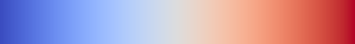

under

bad

over

```python
# Set seaborn themes
sns.set_theme(style='white')
sns.color_palette('coolwarm', as_cmap=True)
```

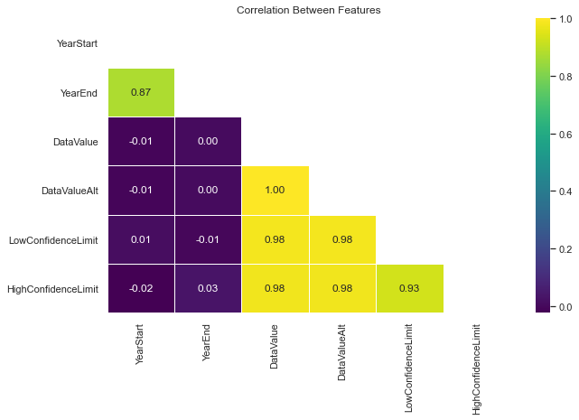

```python
# To get a correlation matrix
# Ploting the heat map
# corr: give the correlation matrix
# cmap: color code used for plotting
# vmax: gives a maximum range of values for the chart
# vmin: gives a minimum range of values for the chart
# annot: prints the correlation values in the chart
# annot_kws={"size": 12}): Sets the font size of the annotation

# Create the plot
plt.figure(figsize=(10,6))
matrix = variableCorr
mask = np.triu(np.ones_like(matrix, dtype=float))
sns.heatmap(variableCorr,
           annot=True,
           linewidths=.5,
           cmap='viridis',
           fmt= '.2f',
           mask=mask)

# Specify the name of the plot
plt.title('Correlation Between Features')
plt.show()
```

- **Are all the values the same color?**

No, the values are not all the same color. There are different shades representing various correlation strengths. Some values are close to 1, indicating strong multicollinearity, particularly among DataValue, DataValueAlt, LowConfidenceLimit, and HighConfidenceLimit. This suggests that these variables are highly related.

- **Are specific variables correlated higher than others?**

- **Are there negative correlations indicating an inverse relationship?**

Yes, there are some negative correlations, but they appear to be weak. For instance, YearStart has a small negative correlation with HighConfidenceLimit (-0.02) and DataValue (-0.01). However, these values are close to zero, suggesting very weak inverse relationships.

- **Does correlation equal causation?**

No, correlation does not imply causation. Just because two variables have a strong correlation does not mean one causes the other. For example, DataValue and LowConfidenceLimit are highly correlated, but this does not mean one directly influences the other it may simply be due to the way the data is structured.

- **Are there variables that lack correlation with others?**

Yes, YearStart and YearEnd show very weak correlations with most of the other variables (close to 0), except for YearEnd with YearStart (0.87).

Additional Statistical methods are possible. Python is a mathematical programming language and can perform inferential statistics, hypothesis testing, probability distributions, and multivariate statistical analysis.

## Visualizations

Create Visualizations to aid in the interpretation of the data and answering of the research problem. Using Python plotting libraries seaborn, matplotlib, plotly, or bokeh multiple plots will be completed to see trends and insights in the data.

- Use charts, graphs, maps, and other plots to answer questions related to your research question.
- Bivariate analysis is the process of examing two variables to visualize their relationship. Choose variables from the correlation matrix to see how they affect each other.
- Be sure to use the correct chart for the type of information you need.

### Choosing a Visualization

The factors for data visualizations have multiple factors to consider when selecting the plot best suited to display the data.

- The type of data:  
  The type of data you are working with will dictate the type of visualization that is most appropriate. For example, if you have categorical data, you might use a bar chart or a pie chart. If you have numerical data, you might use a line chart or a scatter plot.
- The number of variables:  
  If you are visualizing only one variable, you have more flexibility in terms of the type of visualization you can use. However, if you are visualizing multiple variables, you need to choose a visualization that can effectively show the relationships between the variables.
- The goal of the visualization:  
  What do you want the visualization to achieve? Do you want to show trends over time? Do you want to compare different groups of data? Do you want to show the distribution of data? The goal of your visualization will help you to choose the right type of visualization.
- The audience:  
  Who is the audience for your visualization? Are they familiar with data visualization? Do they have a technical background? The audience for your visualization will affect the complexity and level of detail that you use.
- Available tools:  
  What libraries do you have access to? There are many different visualization libraries available for Python, such as Matplotlib, Seaborn, and Plotly. The software you have access to will affect the types of visualizations that you can create.
- Use multiple visualizations:  
  It is often helpful to use multiple visualizations to show different aspects of your data. This can help to tell a more complete story and to make the data more understandable.
- Make sure the visualization is clear and concise:  
  The visualization should be easy to understand at a glance. The labels should be clear and the colors should be consistent.
- Your own preferences:  
  Ultimately, the best visualization is the one that you think is most effective and visually appealing. Don't be afraid to experiment with different types of visualizations until you find one that you like.

### Guide to Stunning Visualizations

It is important that the visualizations created also display content that keep the reader engaged in the research.

- Use a consistent style:  
  Once you have chosen a visualization, use a consistent style throughout your visualization. This will make your visualization look more professional and polished.
- Label your axes:  
  Always label your axes with clear and concise labels. This will help your audience understand what the visualization is showing.
- Use a legend:  
  If your visualization uses multiple colors or shapes, use a legend to identify what each color or shape represents.
- Annotate your visualization:  
  Use annotations to highlight important features of your visualization. This can help your audience understand the data more easily.

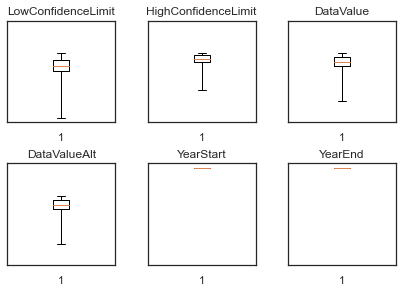

```python
# Generate Box and Whisker chart
# Import matplot lib to generate chart
import matplotlib.pyplot as plt
labels = ['DataValueUnit', 'DataValueType', 'DataValue',
       'DataValueAlt', 'DataValueFootnoteSymbol', 'DataValueFootnote']


# Build the plot:
# two rows of three plots each
fig, axs = plt.subplots(nrows=2, ncols=3, sharey=True)

# first plot, row 1 column 1
axs[0, 0].boxplot(ChronicdeseaseUS['LowConfidenceLimit'])
axs[0, 0].set_title('LowConfidenceLimit')

# second plot, row 1 column 2
axs[0, 1].boxplot(ChronicdeseaseUS['HighConfidenceLimit'])
axs[0, 1].set_title('HighConfidenceLimit')

# third plot, row 1 column 3
axs[0, 2].boxplot(ChronicdeseaseUS['DataValue'])
axs[0, 2].set_title('DataValue')

# fourth plot, row 2 column 1
axs[1, 0].boxplot(ChronicdeseaseUS['DataValueAlt'])
axs[1, 0].set_title('DataValueAlt')

# fifth plot, row 2 column 2
axs[1, 1].boxplot(ChronicdeseaseUS['YearStart'])
axs[1, 1].set_title('YearStart')

# sixth plot, row 2 column 3
axs[1, 2].boxplot(ChronicdeseaseUS['YearEnd'])
axs[1, 2].set_title('YearEnd')

# Designate scale
for ax in axs.flat:
    ax.set_yscale('log')
    ax.set_yticklabels([])

fig.subplots_adjust(left=0.08, right=0.98, bottom=0.05, top=0.9,
                    hspace=0.4, wspace=0.3)
plt.show()
```

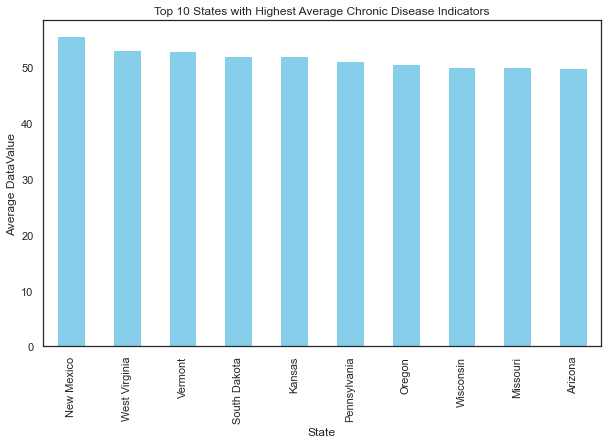

```python
import matplotlib.pyplot as plt
import seaborn as sns

# Group by state and calculate the mean DataValue for each state
state_avg = ChronicdeseaseUS.groupby('LocationDesc')['DataValue'].mean().sort_values(ascending=False)

# Plot the top 10 states with the highest average DataValue
plt.figure(figsize=(10, 6))
state_avg.head(10).plot(kind='bar', color='skyblue')
plt.title('Top 10 States with Highest Average Chronic Disease Indicators')
plt.xlabel('State')
plt.ylabel('Average DataValue')
plt.show()
```

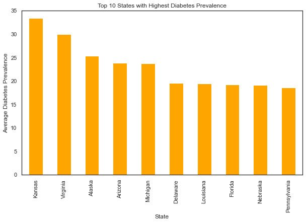

```python
# Filter data for diabetes
diabetes_df = ChronicdeseaseUS[ChronicdeseaseUS['Topic'] == 'Diabetes']

# Group by state and calculate the mean DataValue for diabetes
diabetes_state_avg = diabetes_df.groupby('LocationDesc')['DataValue'].mean().sort_values(ascending=False)

# Plot the top 10 states with the highest diabetes prevalence
plt.figure(figsize=(10, 6))
diabetes_state_avg.head(10).plot(kind='bar', color='orange')
plt.title('Top 10 States with Highest Diabetes Prevalence')
plt.xlabel('State')
plt.ylabel('Average Diabetes Prevalence')
plt.show()
```

```python
# Set Plotly themes
# Javascript Interactive Visualization (computationally expensive)
import plotly.express as px
import plotly.io as pio
pio.templates.default = 'plotly_white'
```

```python
# Set Bokeh themes
# bokeh.palettes.Viridis256
import bokeh as bk
from bokeh.layouts import column
from bokeh.plotting import figure, output_file, show, curdoc
from bokeh.io import output_notebook, push_notebook, show
from bokeh.models import Scatter, ColumnDataSource, Div, RangeSlider, Spinner, CustomJS
# apply theme to current document
curdoc().theme = 'light_minimal'
```

### Research Question:What are the most prevalent chronic diseases in the U.S., and how do they vary by state? Which states have the highest and lowest prevalence rates, and what factors contribute to these differences?

Explain how the technique this visualization uses describes the research question.

Technique: A bar chart is used to display the average prevalence of chronic diseases across the U.S.

How It Answers the Question:

Identifies the most common chronic diseases nationwide. Shows which diseases affect the largest portion of the population, helping to prioritize health interventions. Provides a broad national-level insight before diving into state-level variations.

1. Bar Chart for Disease Prevalence by State

Technique: A state-wise bar chart is used to visualize how a specific disease (e.g., Diabetes) varies across different U.S. states.

How It Answers the Question:

Highlights which states have the highest and lowest prevalence for a given disease. Allows for comparison between different states to understand geographic disparities. Helps identify patterns such as regional clusters with high or low disease prevalence.

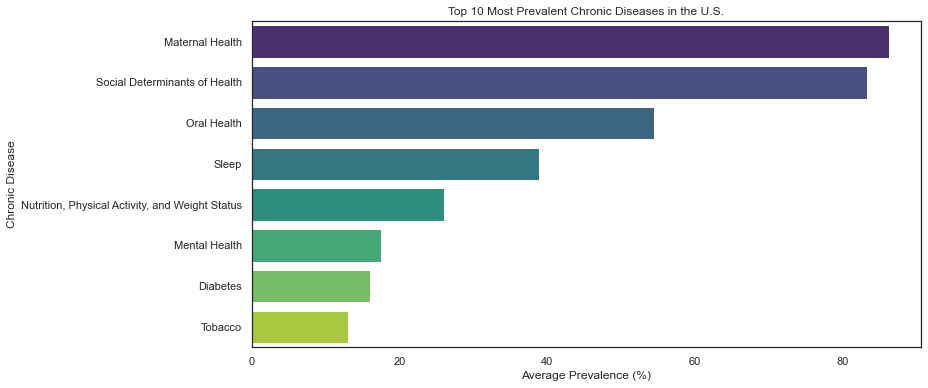

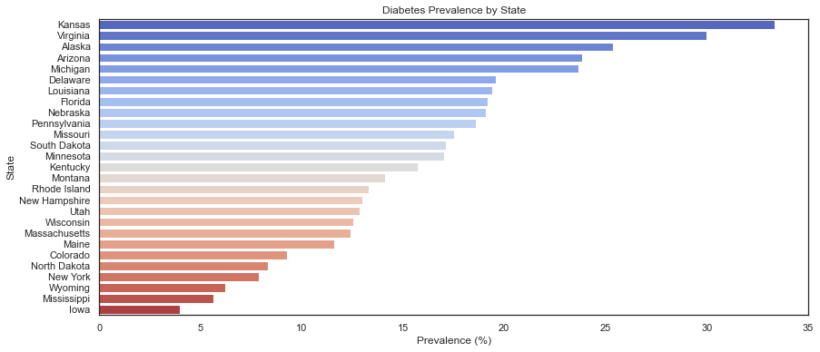

```python
# Select relevant columns (modify if needed)
df_subset = ChronicdeseaseUS[['LocationAbbr', 'LocationDesc', 'Topic', 'DataValue', 'Stratification1', 'StratificationCategory1']]
# Aggregate data to get the mean prevalence per state and disease
disease_state_avg = df_subset.groupby(['LocationDesc', 'Topic'])['DataValue'].mean().reset_index()
# Identify the most prevalent chronic diseases
top_diseases = disease_state_avg.groupby('Topic')['DataValue'].mean().sort_values(ascending=False).head(10)

# Plot the most prevalent chronic diseases
plt.figure(figsize=(12, 6))
sns.barplot(x=top_diseases.values, y=top_diseases.index, palette='viridis')
plt.xlabel("Average Prevalence (%)")
plt.ylabel("Chronic Disease")
plt.title("Top 10 Most Prevalent Chronic Diseases in the U.S.")
plt.show()

# Identify states with highest and lowest prevalence for a specific disease (e.g., Diabetes)
disease_name = "Diabetes"  # Change as needed
disease_by_state = disease_state_avg[disease_state_avg['Topic'] == disease_name].sort_values(by='DataValue', ascending=False)

# Plot states with highest and lowest prevalence for the chosen disease
plt.figure(figsize=(14, 6))
sns.barplot(x=disease_by_state['DataValue'], y=disease_by_state['LocationDesc'], palette='coolwarm')
plt.xlabel("Prevalence (%)")
plt.ylabel("State")
plt.title(f"{disease_name} Prevalence by State")
plt.show()
```

#### Observations

From this visualization, we observe the following:

- Observations from your visualization should be described here.

Maternal Health and Social Determinants of Health have the highest prevalence rates, exceeding 80%. These categories likely encompass various risk factors affecting overall health outcomes. Moderately Prevalent Conditions:

Mental Health, Diabetes, and Tobacco Use have lower prevalence rates but remain major public health concerns. Diabetes and tobacco-related illnesses are well-known contributors to mortality and morbidity in the U.S. Implications:

High prevalence in maternal health and social determinants suggests a need for policy interventions addressing socioeconomic factors. Preventative measures focusing on lifestyle modifications (nutrition, physical activity, and mental health) could help mitigate chronic disease burden.

Iowa and Mississippi have the lowest diabetes prevalence rates. States like Wyoming, New York, and North Dakota also show relatively low prevalence. Geographic Trends:

States with high prevalence may require targeted healthcare interventions and public awareness campaigns. Further investigation is needed to understand the role of factors such as diet, physical activity, healthcare access, and demographics in diabetes prevalence.

### How have chronic disease indicators (e.g., diabetes, asthma, mental health) changed over time, and what are the underlying drivers of these trends?

**Graph 1**: Time Trends in Chronic Disease Prevalence Explain how the technique this visualization uses describes the research question.

Technique: A lineplot is used to display the average prevalence of chronic diseases across the U.S.

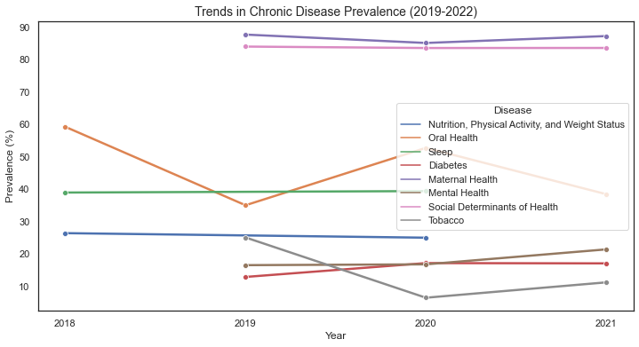

```python
import pandas as pd
import matplotlib.pyplot as plt
import seaborn as sns



# Filter relevant data
topics = ChronicdeseaseUS.Topic.unique()
filtered = ChronicdeseaseUS[
    (ChronicdeseaseUS['Topic'].isin(topics)) &
    (ChronicdeseaseUS['DataValueType'].str.contains("Crude Prevalence|Age-adjusted"))
].copy()

# Clean YearStart (use midpoint if YearEnd differs)
filtered['Year'] = filtered['YearStart']

# Group by Year and Topic
grouped = filtered.groupby(['Year', 'Topic'])['DataValue'].mean().reset_index()

# Plot
plt.figure(figsize=(12, 6))
sns.lineplot(data=grouped, x='Year', y='DataValue', hue='Topic', marker='o', linewidth=2.5)
plt.title("Trends in Chronic Disease Prevalence (2019-2022)", fontsize=14)
plt.xticks(sorted(grouped['Year'].unique()))
plt.ylabel("Prevalence (%)")
plt.xlabel("Year")
plt.legend(title='Disease')
plt.show()
```

#### Observations

From this visualization, we observe the following:

- Observations from your visualization should be described here.

The prevalence of different chronic diseases varies significantly over time.

Some conditions show a decline, while others remain stable or increase.

##### Key Observations

Sleep (Green Line): Appears stable over the years, indicating little variation in prevalence.

Mental Health (Brown Line): Shows a slight upward trend, indicating increasing prevalence.

Nutrition, Physical Activity, and Weight Status (Blue Line): Appears to decline slightly over time.

Implications

The increase in mental health issues suggests a rising concern, possibly influenced by external factors such as the COVID-19 pandemic.

The decline in tobacco use could be due to successful public health policies and awareness campaigns.

The stability of sleep health suggests that sleep-related issues have remained consistent across the years.

**Graph 2: Geographic Variation in Disease Rates**

Explain how the technique this visualization uses describes the research question.

Technique: A barchart is used to how Diabetes and Oral Health Prevalence by states changes over the time .

How It Answers the Question: Reveals whether diseases are rising/falling overall and Show how Diabetes and Oral Health Prevalence by states changed from 2019–2021.

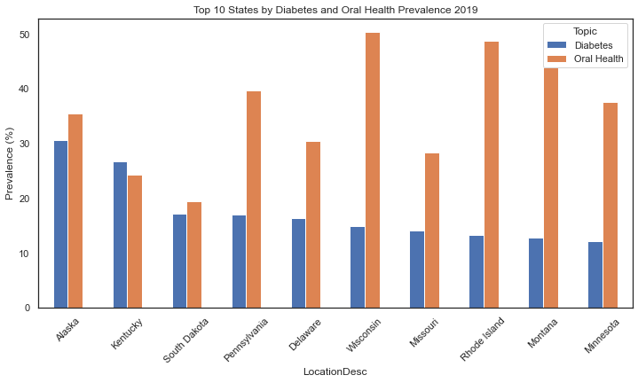

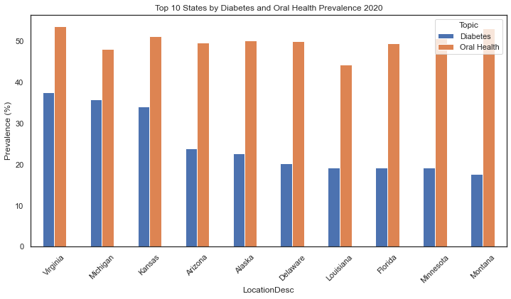

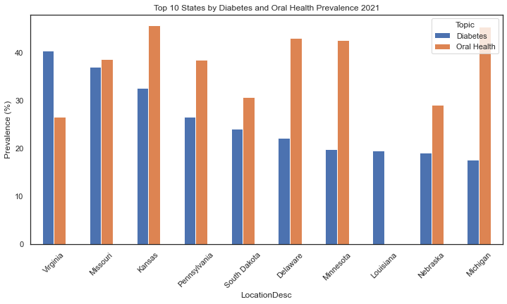

```python
# Filter 2022 data for Diabetes and Asthma
for year in  [2019,2020,2021]:


    df_2021 = ChronicdeseaseUS[
        (ChronicdeseaseUS['YearStart'] == year) &
        (ChronicdeseaseUS['Topic'].isin(["Diabetes", "Oral Health"])) &
        (ChronicdeseaseUS['DataValueType'].str.contains("Crude Prevalence"))
    ]

    # Pivot to compare diseases by state
    pivoted = df_2021.pivot_table(index='LocationDesc', columns='Topic', values='DataValue', aggfunc='mean')

    # Plot top 10 states for Diabetes
    pivoted.sort_values("Diabetes", ascending=False).head(10).plot(
        kind='bar', figsize=(12, 6),
        title="Top 10 States by Diabetes and Oral Health Prevalence " + str(year)
    )
    plt.ylabel("Prevalence (%)")
    plt.xticks(rotation=45)
    plt.show()
```

#### Observations

From this visualization, we observe the following:

- Observations from your visualization should be described here.

Chronic Disease Prevalence from (2019-2021)

Some chronic diseases remained stable, while others fluctuated.

Certain diseases, like Diabetes, had noticeable variations over time.

Top 10 States by Diabetes and Oral Health Prevalence (2019 - 2020)

Some states, such as Wisconsin and Rhode Island, had notably high Oral Health prevalence in 2019.

The ranking of states changed between 2019 and 2020, with some states dropping out and new ones appearing.

### Research Question: Which demographic groups (eg. race/ethnicity) are most affected by specific chronic diseases, and how do socioeconomic factors contribute to these disparities?

Explain how the technique this visualization uses describes the research question.

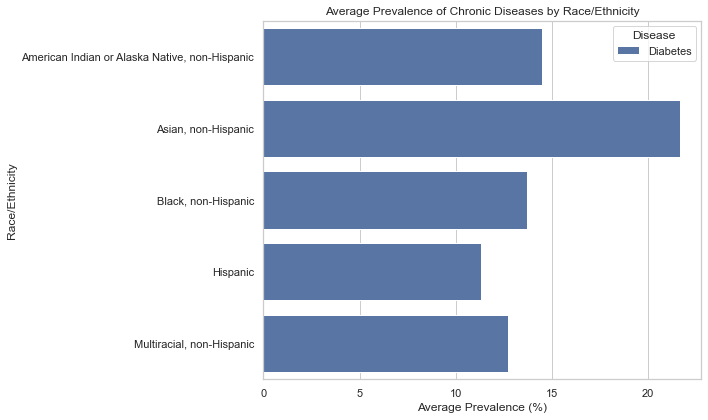

```python
import matplotlib.pyplot as plt
import seaborn as sns

# Set visual style
sns.set(style="whitegrid")

# Prepare a subset for three key demographics: race/ethnicity
demographic_vars = ['Race/Ethnicity']
plots = []

# Create bar plots for each demographic category across chronic diseases
for category in demographic_vars:
    subset = filtered_df[filtered_df['StratificationCategory1'] == category]
    avg_values = (
        subset.groupby(['Topic', 'Stratification1'])['DataValue']
        .mean()
        .reset_index()
    )

    plt.figure(figsize=(10, 6))
    sns.barplot(data=avg_values, x='DataValue', y='Stratification1', hue='Topic')
    plt.title(f'Average Prevalence of Chronic Diseases by {category}')
    plt.xlabel('Average Prevalence (%)')
    plt.ylabel(category)
    plt.legend(title='Disease')
    plt.tight_layout()
    plt.show()
```

```python
# Filter to rows with valid DataValue and some common chronic conditions
chronic_conditions = ['Diabetes', 'Asthma', 'Obesity']
filtered_df = ChronicdeseaseUS[(ChronicdeseaseUS['Topic'].isin(chronic_conditions)) & (ChronicdeseaseUS['DataValue'].notna())]

# Get unique stratifications by topic
strat_summary = (
    filtered_df
    .groupby(['Topic', 'StratificationCategory1', 'Stratification1'])
    .size()
    .reset_index(name='Count')
    .sort_values(['Topic', 'StratificationCategory1'])
)

strat_summary.head(20)
```

|  | Topic | StratificationCategory1 | Stratification1 | Count |
| --- | --- | --- | --- | --- |
| 0 | Diabetes | Race/Ethnicity | American Indian or Alaska Native, non-Hispanic | 4 |
| 1 | Diabetes | Race/Ethnicity | Asian, non-Hispanic | 28 |
| 2 | Diabetes | Race/Ethnicity | Black, non-Hispanic | 5 |
| 3 | Diabetes | Race/Ethnicity | Hispanic | 21 |
| 4 | Diabetes | Race/Ethnicity | Multiracial, non-Hispanic | 16 |

### Observations

X-axis: prevalence values (percentage of population affected).

Color (Hue): represents different chronic diseases.

##### Observation from visual

Highest Diabetes Prevalence: Asian, non-Hispanic group has the highest average prevalence of diabetes among all racial/ethnic groups shown, at over 20%.

1. Moderate to High Prevalence: American Indian or Alaska Native, non-Hispanic

Black, non-Hispanic

These groups have moderate to high prevalence levels (just under 15%).

1. Lower Prevalence: Hispanic and Multiracial, non-Hispanic groups show lower average prevalence levels (~11–12%).

This visualization supports the idea that racial and ethnic disparities exist in the prevalence of diabetes, which is a key chronic disease:

Public health relevance: Indicates a need for targeted intervention in specific communities.

**Research Focus**: Which U.S. states have higher or lower diabetes prevalence?

**Graph 2** : Geographic Disparities in Chronic Disease Prevalence

How this reply the research question : so like we can address question like Which U.S. states have higher or lower diabetes prevalence?

```python
%matplotlib inline
import pandas as pd
import plotly.express as px

# Filter the dataset for diabetes and valid values
df_diabetes_state = ChronicdeseaseUS[
    (ChronicdeseaseUS['Question'] == 'Short sleep duration among children aged 4 months to 14 years') &
    (ChronicdeseaseUS['DataValue'].notna()) &
    (ChronicdeseaseUS['LocationAbbr'].str.len() == 2)  # Keep only valid state codes
]

# Get latest year for each state (in case of multiple entries)
latest_diabetes = df_diabetes_state.sort_values('YearStart', ascending=False).drop_duplicates('LocationAbbr')

# Create choropleth map
fig = px.choropleth(
    latest_diabetes,
    locations='LocationAbbr',
    locationmode="USA-states",
    color='DataValue',
    scope="usa",
    hover_name='LocationDesc',
    color_continuous_scale='Reds',
    labels={'DataValue': 'Diabetes Prevalence (%)'},
    title='Diagnosed Diabetes Prevalence by U.S. State (Most Recent Year)'
)

fig.update_layout(margin={"r":0,"t":40,"l":0,"b":0})
fig.show()
```

[interactive chart not shown]

### Observations

Highlights states with higher burden in darker red.

##### Observation from visual

These groups have moderate to high prevalence levels .

**Research Focus**: Which U.S. regions show high chronic disease prevalence, and how is it distributed spatially?

**Technique** : Plotly Interative Scatter Geo Map

Identify geographic clusters (e.g., high rates in the South).

Hover for exact values.

Compare visually across region

```python
import pandas as pd
import plotly.express as px

# Reference table with state coordinates
state_coords = pd.DataFrame({
    'LocationAbbr': ['AL', 'AK', 'AZ', 'AR', 'CA', 'CO', 'CT', 'DE', 'FL', 'GA',
                     'HI', 'ID', 'IL', 'IN', 'IA', 'KS', 'KY', 'LA', 'ME', 'MD',
                     'MA', 'MI', 'MN', 'MS', 'MO', 'MT', 'NE', 'NV', 'NH', 'NJ',
                     'NM', 'NY', 'NC', 'ND', 'OH', 'OK', 'OR', 'PA', 'RI', 'SC',
                     'SD', 'TN', 'TX', 'UT', 'VT', 'VA', 'WA', 'WV', 'WI', 'WY'],
    'Latitude': [32.8, 61.3, 34.0, 35.2, 36.8, 39.0, 41.6, 38.9, 27.8, 32.2,
                 21.3, 44.1, 40.6, 39.8, 42.0, 38.5, 37.5, 30.9, 45.3, 39.0,
                 42.3, 44.3, 46.7, 32.4, 38.5, 46.9, 41.5, 38.8, 43.2, 40.1,
                 34.5, 43.0, 35.8, 47.6, 40.4, 35.5, 44.0, 41.2, 41.6, 33.8,
                 44.3, 35.7, 31.0, 39.3, 44.3, 37.4, 47.8, 38.6, 44.5, 43.1],
    'Longitude': [-86.8, -149.5, -111.1, -92.5, -119.4, -105.5, -72.7, -75.5, -81.7, -83.1,
                  -157.8, -114.7, -89.4, -86.1, -93.6, -98.0, -85.3, -91.9, -69.4, -76.8,
                  -71.0, -85.6, -94.7, -89.5, -92.6, -110.4, -99.8, -117.0, -71.6, -74.7,
                  -106.2, -75.5, -79.0, -100.4, -82.8, -97.1, -120.5, -77.2, -71.5, -81.2,
                  -100.3, -86.7, -99.9, -111.9, -72.7, -78.5, -120.7, -80.5, -89.6, -107.3]
})

# Filter for most recent diabetes data
df_diabetes = ChronicdeseaseUS[
    (ChronicdeseaseUS['Question'] == 'Short sleep duration among children aged 4 months to 14 years') &
    (ChronicdeseaseUS['DataValue'].notna())
].copy()

latest_diabetes = df_diabetes.sort_values('YearStart', ascending=False).drop_duplicates('LocationAbbr')

# Merge with coordinates
map_data = pd.merge(latest_diabetes, state_coords, on='LocationAbbr')

# Plot geographic scatter map
fig = px.scatter_geo(
    map_data,
    lat='Latitude',
    lon='Longitude',
    text='LocationDesc',
    hover_name='LocationDesc',
    size='DataValue',
    color='DataValue',
    color_continuous_scale='Reds',
    projection='albers usa',
    title='Geographic Distribution of Diabetes Prevalence in the U.S. (By State)',
    labels={'DataValue': 'Prevalence (%)'}
)

fig.update_geos(fitbounds="locations", visible=False)
fig.update_layout(margin={"r":0,"t":40,"l":0,"b":0})
fig.show()
```

[interactive chart not shown]

### Observations

provide How disease burden is distributed spatially across states.

Provides a visual baseline for targeting regional health disparities.

##### Observation from visual

High Prevalence States (Darker and Larger Bubbles):

Moderate Prevalence:

States like Nevada, Louisiana, Missouri, and New Mexico have medium-sized, medium-red bubbles.

Low Prevalence States (Smaller and Lighter Bubbles):

# **Executive Summary**

## *Chronic Disease Disparities in the United States*

### Purpose

The central question guiding our analysis is:

> **How do the prevalence, trends, and demographic disparities of chronic diseases vary across U.S. states and populations, and what underlying factors drive these patterns?**

### Recommendations

1. **Targeted Screenings & Education:** Deploy mobile clinics and telehealth kiosks to the top 20% of hotspot counties in partnership with local health centers.
2. **Equity-Driven Funding:** Adjust funding formulas to weigh resources by measured disparity indices—race, income, rurality.
3. **Real-Time Monitoring:** Launch an open, interactive dashboard updating chronic disease metrics quarterly to drive accountability and rapid response.

### Conclusion

This executive summary distills a comprehensive data analysis into a narrative of disparity and possibility. By mapping who suffers most and why we offer a clear roadmap for directing resources, shaping policy, and driving measurable progress toward health equity. Behind each data point lies a person or community in need; this work charts the path to a more just and healthier future for all.